# Metody Bayesowskie - projekt II

Karol Doliński, Magdalena Smalarz, Małgorzata Warczyńska

Informatyka i Ekonometria

# 1 Wprowadzenie

Model regresji wielorakiej jest jednym z popularniejszych modeli stosowanych do opisu i predykcji wybranej cechy. Klasycznym podejściem jest estymacja modelu za pomocą Metody Najmniejszych Kwadratów. Z kolei wnioskowanie bayesowskie to metoda wnioskowania statystycznego, w której wykorzystuje się zarówno dane jak i prawdopodobieństwo *a priori* uzyskane np. z poprzednich badań. Celem niniejszego projektu jest zastosowanie wnioskowania bayesowskiego w modelu regresji wielorakiej, a następnie porównanie otrzymanych wyników, w szczególności tych dotyczących prognoz.

# 2 Zbiór danych

Dane wykorzystane w badaniu zawierają 80 obserwacji (z czego 5 zostanie wykorzystanych do prognozy), z których każda jest opisana za pomocą 4 zmiennych:

- cena – cena danego telefonu (w PLN);
- pamiec – ilość pamięci w danym telefonie (w GB);
- PPI – liczba pikseli przypadająca na cal długości, określa rozdzielczość;
- lcd – zmienna binarna, przyjmuje wartość 1 jeśli ekran jest ekranem typu LCD, 0 – jeśli inny.

Dane zostały zostały zebrane w dniu 24 maja 2022 roku z dwóch stron internetowych:

- https://www.x-kom.pl/ zmienne: cena, pamiec;
- https://phonesdata.com/pl/ zmienne: PPI, lcd

Przy gromadzeniu danych odnośnie ceny smartfonów nie uwzględniono akcji promocyjnych sklepu dotyczących niektórych z badanych urządzeń.

# 3 Parametry rozkładu a priori

Rozkład *a priori* to rozkład parametrów przyjęty przed rozpocząciem badania i prezentuje wstępną wiedzę o badanym zjawisku. W związku z tym zdecydowano się na wykorzystanie modelu stworzonego 2 lata temu w oparciu o te same zmienne objaśniające. Wartości zmiennych cena, pamięć, PPI były w tym modelu zlogarytmowane.

|  | Wartość wyestymowanego parametru | Błąd standardowy | P-value testu istotności parametru |
| --- | --- | --- | --- |
| $stała$ | -1.9383 | 1.8348 | 0.2942 |
| $pamięć$ | 0.4771 | 0.0831 | 0.0000 |
| $PPI$ | 1.2528 | 0.3272 | 0.0003 |
| $lcd$ | -0.3635 | 0.1120 | 0.0018 |

Tab. 1.: Wartości wyestymowanych parametrów modelu MNK sprzed 2 lat wraz z oceną ich istotności

Model przyjmuje postać:
$$Y = -1,94 +
0,48~X_1+1,25~X_2 - 0,36~X_3$$
gdzie:

- $Y$ - zmienna objaśniana - cena (zlogarytmowana),
- $X_1$ - zmienna pamięć (zlogarytmowana),
- $X_2$ - zmienna PPI (zlogarytmowana),
- $X_3$ - zmienna lcd.

Można zauważyć, że wszystkie zmienne modelu są statystycznie istotne, a zatem metodami bayesowskimi będziemy szacować wszystkie trzy parametry: pamiec, PPI i lcd.

Jeżeli przyjmiemy następujące rozkłady *a priori*:
$$\pi(\sigma^2) \sim
IG(\frac{\alpha_0}{2},\frac{\delta_0}{2})$$
czyli $\sigma^2$ ma rozkład odwrotny gamma z parametrami $\frac{\alpha_0}{2}$ i $\frac{\delta_0}{2}$,
$$\pi(\beta|\sigma^2) \sim
N_k(\beta_0,\sigma^2\Sigma_0)$$
$\beta_0$ ma $k$-wymiarowy rozkład normalny warunkowy względem $\sigma^2$

to:

- $\beta_0$ - wektor oszacowany MNK we wcześniejszym badaniu,
- $\Sigma_0$ - macierz $(X^{T}X)^{-1}$ uzyskanej z wcześniejszych badań,
- $\alpha_0$ - liczba stopni swobody $(n-k)$ wcześniejszych badań,
- $\delta_0$ - suma kwadratów reszt z wcześniejszego badania.

|  | $\alpha_0$ | $\delta_0$ |
| --- | --- | --- |
| Wartość parametru | 75 | 13.08286 |

Tab. 2.: Wartości $\alpha_0$ i $\delta_0$ rozkładu a priori

|  | $\beta_0$ |
| --- | --- |
| $stała$ | -1.9383419 |
| $pamięć$ | 0.4770800 |
| $PPI$ | 1.2527843 |
| $lcd$ | -0.3634876 |

Tab. 3.: Wartość $\beta_0$ rozkładu a priori

|  | $X_0$ | $X_1$ | $X_2$ | $X_3$ |
| --- | --- | --- | --- | --- |
| $X_0$ | 19.3000562 | 0.2266906 | -3.3682146 | -0.4501900 |
| $X_1$ | 0.2266906 | 0.0396064 | -0.0701662 | 0.0155358 |
| $X_2$ | -3.3682146 | -0.0701662 | 0.6138008 | 0.0575937 |
| $X_3$ | -0.4501900 | 0.0155358 | 0.0575937 | 0.0719283 |

Tab. 4.: Wartość $\Sigma_0$ rozkładu a priori

# 4 Model MNK

|  | Wartość wyestymowanego parametru | Błąd standardowy | P-value testu istotności parametru |
| --- | --- | --- | --- |
| $stała$ | -2.5849 | 1.8142 | 0.1586 |
| $pamięć$ | 0.5535 | 0.0828 | 0.0000 |
| $PPI$ | 1.3185 | 0.3275 | 0.0001 |
| $lcd$ | -0.2409 | 0.1079 | 0.0288 |

Tab. 5.: Wartości wyestymowanych parametrów modelu MNK wraz z oceną ich istotności

- $Y$ - zmienna objaśniana - cena (zlogarytmowana),
- $X_1$ - zmienna pamięć (zlogarytmowana),
- $X_2$ - zmienna PPI (zlogarytmowana),
- $X_3$ - zmienna lcd.

## 4.1 Weryfikacja modelu

Normalność reszt, test Shapiro-Wilka. Hipotezy:

$H_0:$ reszty modelu mają rozkład normalny

$H_1:$ reszty modelu nie mają rozkładu normalnego

|  | Test Shapiro-Wilka |
| --- | --- |
| P-value | 0.2716132 |

Tab. 6.: P-value dla testu normalności Shapiro-Wilka

Otrzymane p-value powyżej przyjętego poziomu istotności wskazuje na brak podstaw do odrzucenia hipotezy zerowej. Reszty modelu mają rozkład normalny.

Homostekastyczność, test Breuscha-Pagana. Hipotezy:

$H_0:$ reszty modelu są homoskedastyczne

$H_1:$ reszty modelu są heteroskedastyczne

|  | Test Breuscha-Pagana |
| --- | --- |
| P-value | 0.771176 |

Tab. 7.: P-value dla testu jednorodności wariancji Breuscha-Pagana

P-value większe niż 0.05 nie daje podstaw do odrzucenia hipotezy zerowej. Reszty modelu są homoskedastyczne.

Testu na autokorelację reszt nie przeprowadzono z uwagi na wykorzystanie w badaniu danych przekrojowych. Zjawisko autokorelacji polega na zależności bieżących wartości składnika losowego od wartości przeszłych i dotyczy szeregów czasowych.

Model można uznać za prawidłowy i na jego podstawie wyznaczyć paramtery rozkładu *a posteriori*.

# 5 Parametry rozkładu a posteriori

Rozkład *a posteriori* stanowi modyfikacje rozkładu *a priori* po uwzględnieniu drugiej części danych, które służą aktualizacji wiedzy o rozkładzie parametrów.

Rozkład *a posteriori* jest rozkładem normalnym-odwrotnym gamma z następującymi parametrami:

$\Sigma_1 = ((X^{T}X)^{-1} +\Sigma_0^{-1})^{-1}$  
$\beta_1 = \Sigma_1(X^TY + \Sigma_0^{-1}\beta_0)$  
$\alpha_1 = \alpha_0 + n$  
$\delta_1 = \delta_0 + Y^TY - \beta_1^T\Sigma_1^{_1}\beta_1 + \beta_0^T\Sigma_0^{_1}\beta_0$

|  | $\alpha_1$ | $\delta_1$ |
| --- | --- | --- |
| Wartość parametru | 150 | 26.06974 |

Tab. 8.: Wartości $\alpha_1$ i $\delta_1$ rozkładu a posteriori

|  | $\beta_1$ |
| --- | --- |
| $stała$ | -2.3429037 |
| $pamięć$ | 0.5159045 |
| $PPI$ | 1.2980797 |
| $lcd$ | -0.2971418 |

Tab. 9.: Wartość $\beta_1$ rozkładu a posteriori

|  | $X_0$ | $X_1$ | $X_2$ | $X_3$ |
| --- | --- | --- | --- | --- |
| $X_0$ | 9.7486705 | 0.1286071 | -1.7130503 | -0.2113765 |
| $X_1$ | 0.1286071 | 0.0201527 | -0.0378619 | 0.0071532 |
| $X_2$ | -1.7130503 | -0.0378619 | 0.3139694 | 0.0269906 |
| $X_3$ | -0.2113765 | 0.0071532 | 0.0269906 | 0.0354028 |

Tab. 10.: Wartość $\Sigma_1$ rozkładu a posteriori

# 6 Wyznaczenie rozkładów brzegowych

Poprzednie obliczenia pozwoliły na uzyskanie łącznego rozkładu *a posteriori* parametrów $(\beta, \sigma^2)$. Rozkłady brzegowe pozwalają na wyznaczenie rozkładów rozłącznych dla $\sigma^2$ oraz każdego $\beta$.

Rozkłady brzegowe *a priori* i *a posteriori* przedstawiono na wspólnych wykresach w celu porównania.

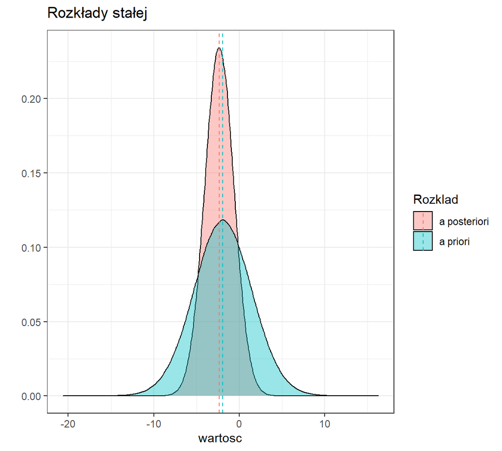

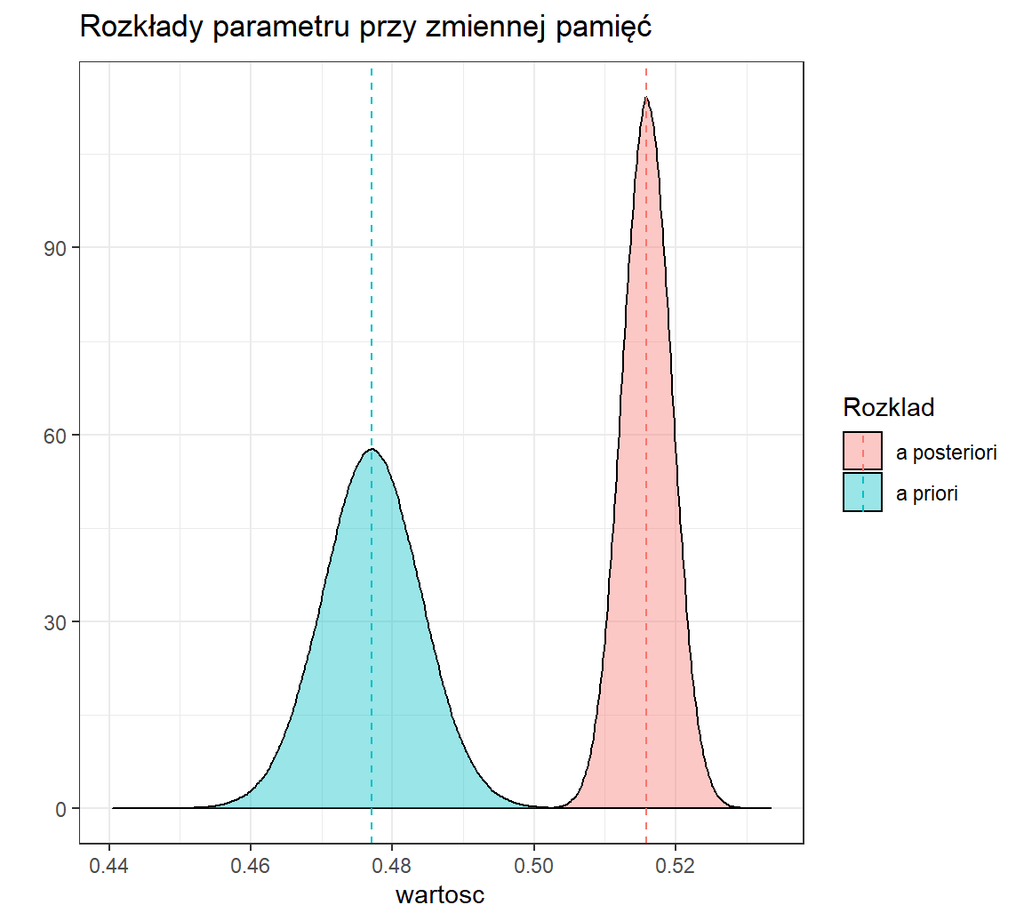

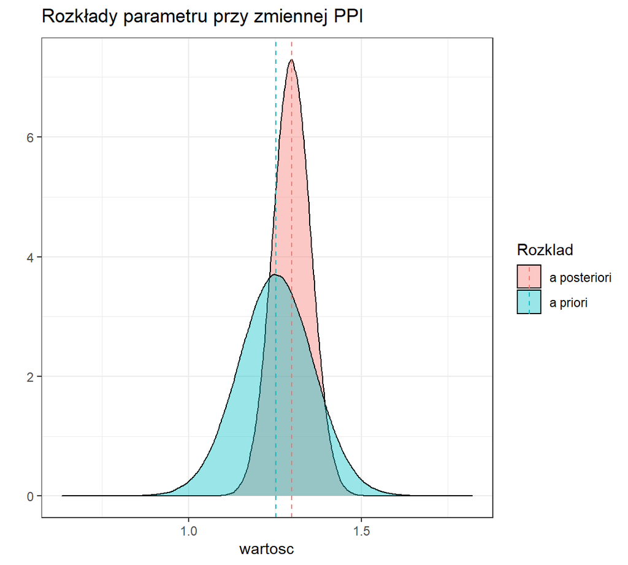

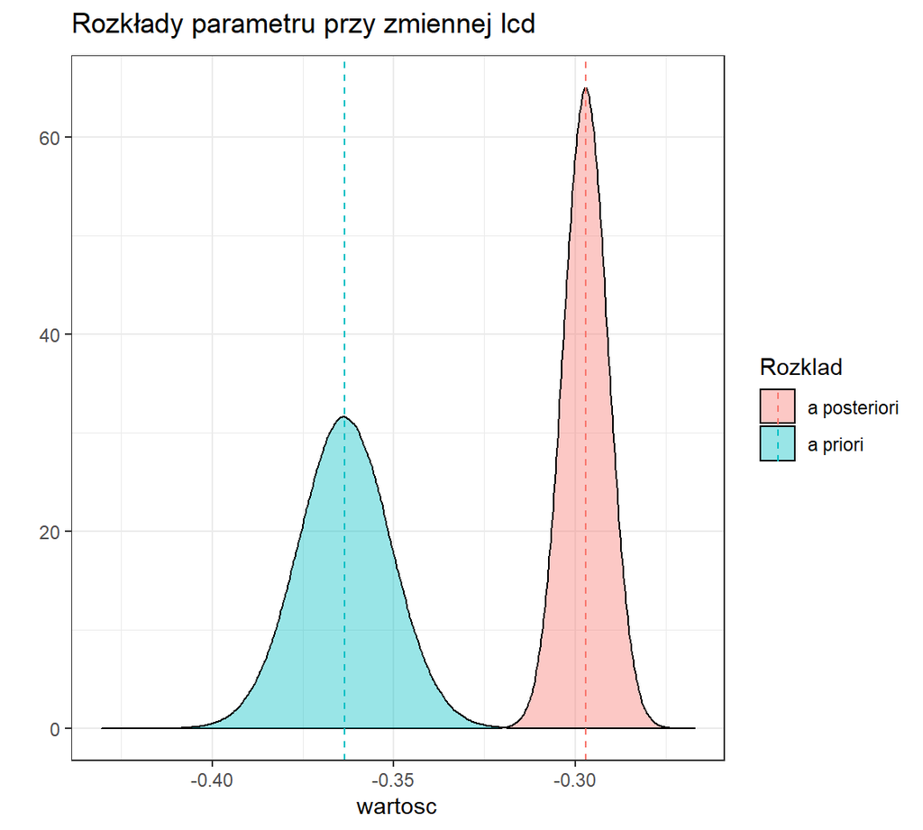

Na wykresach widać, że rozkłady parametrów *a posterioi* są znacznie węższe od rozkładów *a priori*. Wykresy stałej oraz parametru przy zmiennej *PPI* oscylują wokół podobnych wartości, natomiast parametry zmiennych *pamięć* i *lcd* są różne w przypadku rozkładu *a priori* i *a posteriori*.

# 7 Bayesowskie estymatory parametrów

Estymatory bayesowskie parametrów modelu są wartościami oczekiwanymi obliczonymi z wykorzystaniem rozkładku *a posteriori*.

|  | Estymator bayesowski |
| --- | --- |
| $stała$ | -2.3450016 |
| $pamięć$ | 0.5159036 |
| $PPI$ | 1.2981317 |
| $lcd$ | -0.2971388 |

Tab. 11.: Estymatory bayesowskie parametrów modelu MNK

Model przyjmuje postać:
$$Y = -2,34 +
0,52~X_1+1,30~X_2 - 0,30~X_3$$
gdzie:

- $Y$ - zmienna objaśniana - cena (zlogarytmowana),
- $X_1$ - zmienna pamięć (zlogarytmowana),
- $X_2$ - zmienna PPI (zlogarytmowana),
- $X_3$ - zmienna lcd.

Interpretacja parametrów:

- wzrost pamięci o 1% powoduje wzrost ceny o około 0,52%, ceteris paribus;
- wzrost PPI o 1% powoduje wzrost ceny o około 1,30%, ceteris paribus;
- cena telefonu z ekranem lcd jest niższa o okolo 0,30 jednostki, ceteris paribus.

Warto zauważyć, iż oszacowania parametrów obu modeli są dosyć podobne. Ponadto znak przy parametrze dla danej zmiennej jest taki sam w obu modelach. Oznacza to, iż na podstawie obu modeli można wyciągnąć ten sam wniosek, czy wraz ze wzrostem danej zmiennej objaśniającej zmniejsza się lub zwiększa się wartość zmiennej objaśnianej.

Jedną z metod weryfikacji wyznaczonych estymatorów bayesowskich jest wyznaczenie 95% przedziałów ufności największej gęstości *a posteriori* czyli HDPI (Highest Posterior Density Interval).

|  | Dolna granica HPDI | Górna granica HPDI |
| --- | --- | --- |
| $stała$ | -5.6730788 | 1.0185013 |
| $pamięć$ | 0.5089872 | 0.5228284 |
| $PPI$ | 1.1902459 | 1.4055609 |
| $lcd$ | -0.3092944 | -0.2849686 |

Tab. 12.: HPDI

Przedziały HPDI dla zmiennych objaśniających nie zawierają 0 - oznacza to, że wszystkie analizowane zmienne można uznać za statystycznie istotne. Pokrywa się to z wynikiem otrzymanym dzięki Klasycznej Metodzie Najmniejszych Kwadratów.

Następnie wyznaczono przedziały ufności dla modelu MNK.

|  | Dolna granica przedziału ufności | Górna granica przedziału ufności |
| --- | --- | --- |
| $stała$ | -6.2022405 | 1.0324623 |
| $pamięć$ | 0.3884640 | 0.7185348 |
| $PPI$ | 0.6654115 | 1.9716179 |
| $lcd$ | -0.4560893 | -0.0257022 |

Tab. 13.: Przedziały ufności modelu MNK

Przedziały ufności dla obu metod różnią się od siebie, jednak różnice te nie są znaczące. W przypadku wszystkich składowych modelu przedziały HPDI mają węższy zakres.

# 8 Rozkłady predykcyjne

W podejściu bayesowskich prognozowane wartości są zmiennymi losowymi, dla których należy wyznaczyć rozkład predykcyjny. Znana funkcja gęstości *a posteriori* parametrów modelu i $y_{\tau}$ pozwalają na wyznaczenie $m$-wymiarowego rozkładu predykcyjnego.

$$f(y_{\tau}|y)\sim
t_m(x_{\tau}\beta_1,~\frac{\delta_1}{\alpha_1}[I_m+x_{\tau}\Sigma_1x_{\tau}^T],~\alpha_1)$$
gdzie:

$\beta_1$, $\Sigma_1$, $\alpha_1$, $\delta_1$ są parametrami rozkładu *a posteriori*, a $I_m$ jest $m$-wymiarową macierzą jednostkową.

Z wykorzystaniem wcześniej wspomnianego rozkładu wyznaczono prognozy, których wartości oczekiwane przedstawiono w tabeli poniżej, a następnie porównano je z prognozami uzyskanymi metodą klasyczną.

|  | Wartość prognozy | Dolna granica HPDI | Górna granica HPDI |
| --- | --- | --- | --- |
| I | 7.060198 | 6.695931 | 7.428231 |
| II | 7.017529 | 6.663931 | 7.362740 |
| III | 7.755729 | 7.402713 | 8.111535 |
| IV | 7.944213 | 7.597255 | 8.292518 |
| V | 8.288652 | 7.936808 | 8.638770 |

Tab. 14.: Prognoza - wnioskowanie bayesowskie

|  | Wartość prognozy | Dolna granica przedziału ufności | Górna granica przedziału ufności |
| --- | --- | --- | --- |
| I | 7.088849 | 6.794728 | 7.382970 |
| II | 7.106264 | 6.954711 | 7.257817 |
| III | 7.795418 | 7.586612 | 8.004224 |
| IV | 8.007117 | 7.873795 | 8.140440 |
| V | 8.377589 | 8.200383 | 8.554794 |

Tab. 15.: Wartości prognozy z modelu MNK oraz przedziały ufności

Wartości wyznaczonych prognoz przedstawiono również w sumarycznej tabeli uwzględniajacej wartości rzeczywiste:

|  | Wartość rzeczywista | Prognoza bayesowska | Prognoza MNK |
| --- | --- | --- | --- |
| I | 6.955593 | 7.060198 | 7.088849 |
| II | 8.459352 | 7.017529 | 7.106264 |
| III | 8.846353 | 7.755729 | 7.795418 |
| IV | 7.658700 | 7.944213 | 8.007117 |
| V | 7.999343 | 8.288652 | 8.377589 |

Tab. 16.: Porównanie wartości rzeczywistych i otrzymanych prognoz

|  | MAE | MSE | RMSE |
| --- | --- | --- | --- |
| KMNK | 0.6527887 | 0.6435070 | 0.8021889 |
| model bayesowski | 0.6423753 | 0.6888954 | 0.8299972 |

Tab. 17.: Błędy prognoz

Zestawienie pokazuje, że wyniki uzyskane obiema metoda dają podobne błędy predykcji. Średni absoltuny błąd predykcji jest mniejszy dla wyników uzyskanych za pomocą estymacji bayesowskiej, z kolei błąd średniokwadratowy (bardziej wyczulony na wartości skrajne) za lepszy wskazał model uzyskany KMNK.

# 9 Porównywanie modeli

Podejście bayesowskie umożliwia porównywanie dwóch modeli (bez i z restrykcjami) w celu oceny, który z nich jest lepszy. Aby porównać dwa modele $M_1$ i $M_2$ stosuje się iloraz szans a posteriori:
$$R_{12}
= \frac{P(y|M_1)}{P(y|M_2)} * \frac{P(M_1)}{P(M_2)}$$

Następnie w oparciu o statystykę $log_{10}R_{12}$ ocenia się, który model jest lepszy. Jeżeli $log_{10}R_{12} > 2$, to model $M_1$ jest zdecydowanie lepszy niż $M_2$.

## 9.1 Istotność zmiennej pamięć

Niech modelem $M_1$ będzie model zawierający wszystkie trzy zmienne objaśniające, a modelem $M_2$ będzie model ze zmiennymi *PPI* orax *lcd*. Zostanie przeprowadzony test restrykcji sprawdzający istotność zmiennej *pamięć*.

| Logarytm statystyki $R_{12}$ |
| --- |
| 7.281474 |

Tab. 18.: Obliczona statystyka testu restrykcji: istotność zmiennej pamięć

Logarytm statystyki większy niż 2 wzkazuje na interpretację rozstrzygającą. Oznacza to, że model bez restrykcji jest lepszy niż model z restrykcjami. Zmienna *pamięć* jest zmienną istotną.

Istotność zmiennej *pamięć* weryfikowano również testem t-Studenta (dla modelu oszacowanego za pomocą MNK). Hipotezy:

$H_0:$ $\alpha_j = 0$ (zmienna nieistotna)

$H_1:$ $\alpha_j \neq 0$ (zmienna istotna)

|  | P-value testu t-Studenta |
| --- | --- |
| $stała$ | 0.1586 |
| $pamięć$ | 0.0000 |
| $PPI$ | 0.0001 |
| $lcd$ | 0.0288 |

Tab. 19.: Wartości testu t-Studenta

Na podstawie testu istotności oszacowanych parametrów można stwierdzić, iż zmienna *pamięć* jest istotna statystycznie ponieważ ma p-value mniejsze niż przyjęty poziom istotności. Jest to wynik zgodny z wcześniej przeprowadzonym testem restrykcji.

## 9.2 Łączna istotność zmiennych pamięć i PPI

Niech modelem $M_1$ będzie model zawierający wszystkie trzy zmienne objaśniające, a modelem $M_2$ będzie model ze zmienną *lcd*. Zostanie przeprowadzony test restrykcji sprawdzający łączną istotność zmiennych *pamięć* i *PPI*.

| Logarytm statystyki $R_{12}$ |
| --- |
| 14.84176 |

Tab. 20.: Obliczona statystyka testu restrykcji: łączna istotność zmiennych pamięć i PPI

Logarytm statystyki większy niż 2 wzkazuje na interpretację rozstrzygającą. Oznacza to, że model bez restrykcji jest lepszy niż model z restrykcjami. Zmienne *PPI* i *pamiec* są zmiennymi istotnymi.  
Przeprowadzony test porównano również z testem F, którego statystyka ma postać:

$$F=\frac{RRSS-URSS}{URSS}\cdot\frac{n-k}{m}$$
gdzie:

- $RRSS$ - suma kwadratów reszt modelu z nałożonymi restrykcjami,
- $URSS$ - suma kwadratów reszt modelu bez restrykcji.

Hipotezy testu:
$$H_0:R\beta=q$$
$$H_1:R\beta\neq q$$

Ich weryfikacja pozwala rozstrzygnąc czy nałożone restrykcje są zasadne.

|  | Test F |
| --- | --- |
| P-value | 0 |

Tab. 22.: P-value dla testu F

P-value wynosi 0 (w zaokrągleniu do części dziesięciotysięcznych), występują podstawy do odrzucenia hipotezy zerowej, co oznacza, że restrykcje są zbędne. Wynik potwierdził wniosek z poprzedniego testu.

# 10 Podsumowanie

Parametrów w telefonie jest kilkadziesiąt, różnią się specyfikacją, dlatego problem prognozowania cen smartfonów jest trudny. Nie tylko dane techniczne odgrywają istotną rolę w kształtowaniu ceny, a inne cechy są trudno mierzalne. Wiele osób używa sformułowania „płacenie za markę”, czyli domniemane dodatkowe pieniądze, które trzeba dopłacić przy zakupie urządzenia topowego producenta – co jest trudne do przedstawienia wartościowo. Ceny w Polsce są również uzależnione od warunków celno-skarbowych. Wbrew pozorom istnieje szereg czynników, które wpływają na ceny smartfonów w Polsce i nie są to tylko parametry techniczne telefonu.

# 11 Bibliografia

- Decewicz Anna, Groniowska Agnieszka,*“Bayesowska analiza statystyczna w badaniach koniunktury gospodarczej”*, Prace i Materiały Instytutu Rozwoju Gospodarczego / Szkoła Główna Handlowa, nr 70, Warszawa, 2001
- Materiały zamieszczone na platformie UPEL w ramach zajęć *Metody Bayesowskie*